# El ADN del Éxito: ¿Qué Empresas Sobreviven en el Estado de México?

Un Diagnóstico Predictivo para Salvar Empleos y Fortalecer la Economía

Autores: Gutierrez Fernandez, Jesus Osmar y Marcelo Porcayo, Tonancy Lizahaya | Especialistas del Comportamiento

02 de Octubre de 2025

## El Desafío: ¿Por Qué Fracasan las Nuevas Empresas?

Cada año, miles de emprendedores en el Estado de México inician un negocio con la esperanza de crecer, generar empleos y fortalecer la economía. Sin embargo, la realidad es dura: una alta proporción de estas empresas no sobrevive sus primeros años. Esta “fuga” de potencial representa un costo enorme para la región.

Para combatir este problema, realizamos un **análisis de supervivencia** —una técnica estadística avanzada— para decodificar el ADN del éxito y el fracaso empresarial. Nuestro objetivo: pasar de apoyos genéricos a **intervenciones quirúrgicas** que protejan a los más vulnerables.

## El Hallazgo Clave: Un Mapa para Navegar el Riesgo

Nuestro análisis revela que el riesgo no está distribuido de manera uniforme. El **sector económico** y el **tamaño inicial** de una empresa son factores críticos que, al combinarse, crean un claro “mapa de riesgo”.

El siguiente gráfico muestra la probabilidad de que una empresa sobreviva sus primeros 12 meses. Los colores verdes indican alta probabilidad de éxito, mientras que los colores más cálidos (amarillo, rojo) señalan una zona de alto peligro.

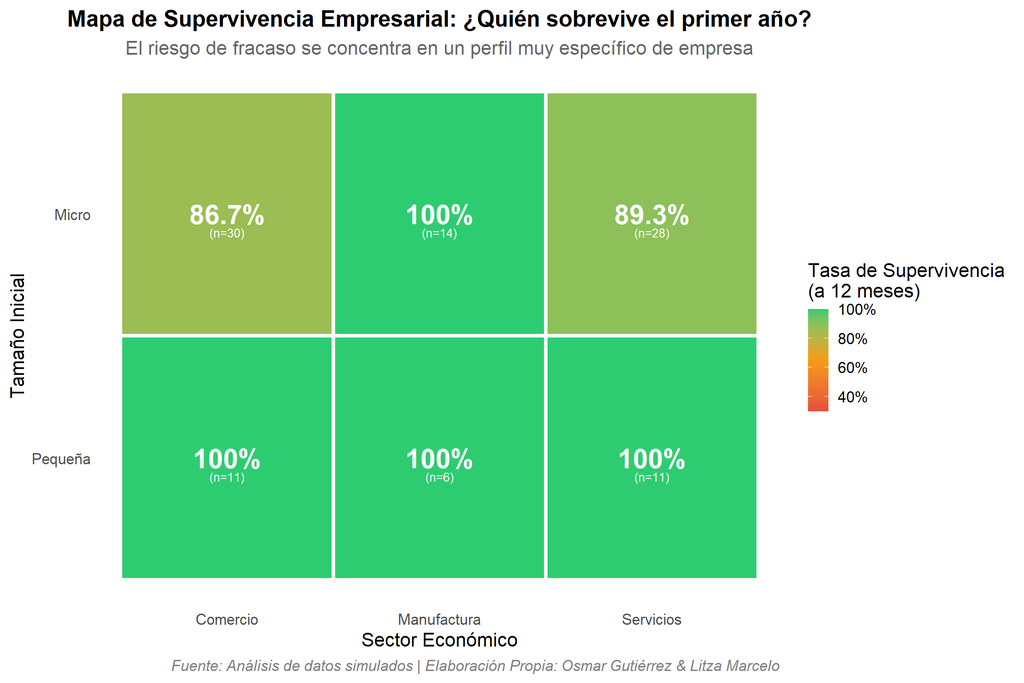

## De los Datos a la Decisión: Una Estrategia Focalizada

#### Propuesta Estratégica: **Programa de Intervención de Alto Impacto**

En lugar de dispersar recursos, proponemos la creación de un **“Programa de Aceleración para el Comercio Minorista”**, enfocado exclusivamente en el perfil de mayor riesgo identificado: **Microempresas del sector Comercio**.

Este programa ofrecería: * **Capacitación Especializada:** En gestión de inventarios, marketing digital y formalización fiscal. * **Micro-créditos de Transición:** Financiamiento de bajo interés condicionado a la adopción de tecnología básica.

Al concentrar la inversión en el epicentro del problema, maximizamos el retorno de cada peso invertido, lo que se traduce directamente en **más empresas que sobreviven, más empleos que se conservan y una economía regional más fuerte y resiliente.**